# IODS course project

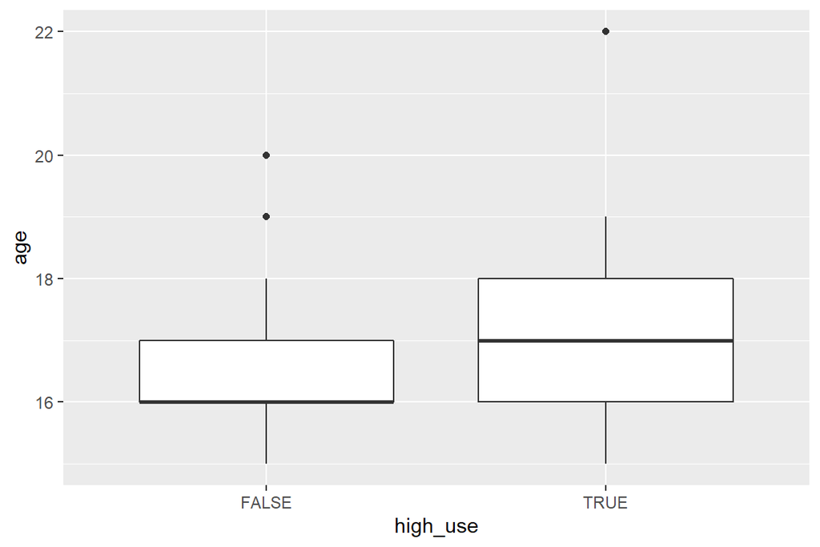

```r
p2 + geom_boxplot()
```

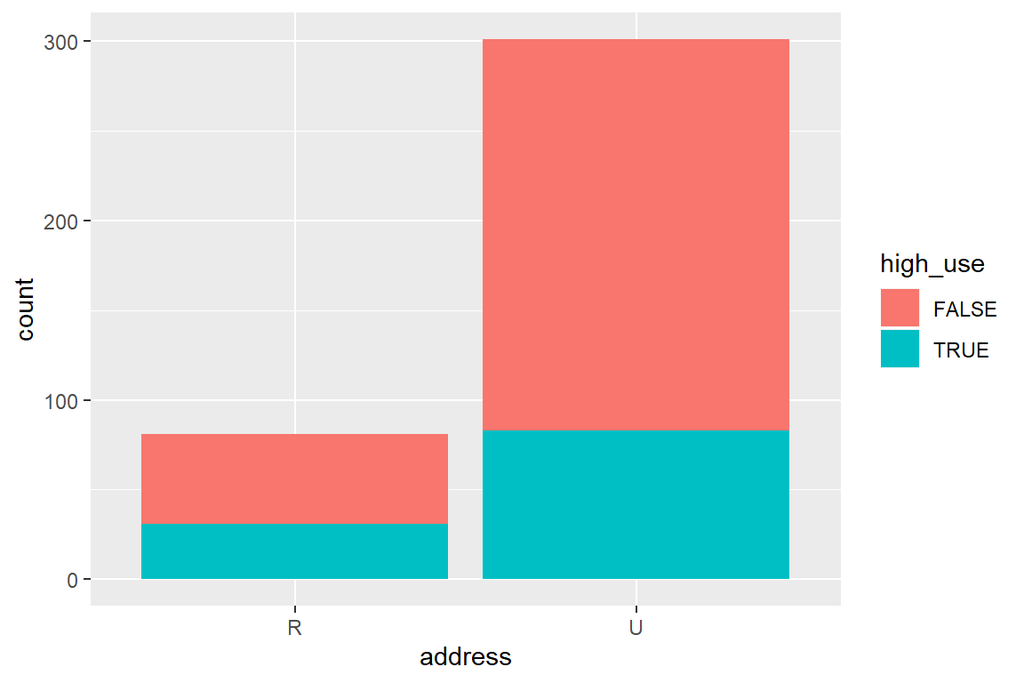

```r
p3 + geom_bar()
```

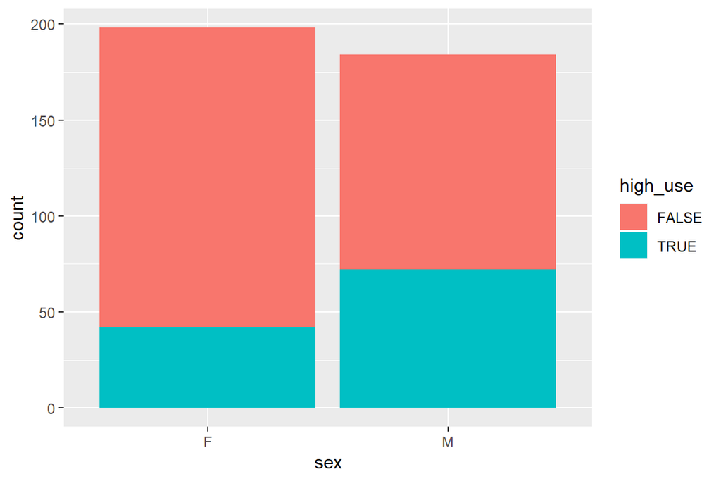

```r
p4 + geom_bar()
```

```r
table(alcs$high_use, alc$sex)
```

```
##
##           F   M
##   FALSE 156 112
##   TRUE   42  72
```

```r
table(alcs$high_use, alc$address)
```

```
##
##           R   U
##   FALSE  50 218
##   TRUE   31  83
```

Based on the explorations, it looks like one of the hypotheses will fail. It looks like there are more heavy drinkers among rural compared to urbam students.

On the next tab, we will get our hand dirty with the regression model.

## Build Logistic regression

```r
# build the model
m <- glm(data=alcs, high_use ~ sex + address + absences + age, family="binomial")
summary(m)
```

```
##
## Call:
## glm(formula = high_use ~ sex + address + absences + age, family = "binomial",
##     data = alcs)
##
## Deviance Residuals:
##     Min       1Q   Median       3Q      Max
## -2.4240  -0.8261  -0.6250   1.0505   2.1305
##
## Coefficients:
##             Estimate Std. Error z value Pr(>|z|)
## (Intercept) -4.00961    1.76034  -2.278   0.0227 *
## sexM         0.98222    0.24136   4.070 4.71e-05 ***
## addressU    -0.41405    0.28094  -1.474   0.1405
## absences     0.09283    0.02325   3.992 6.56e-05 ***
## age          0.15088    0.10240   1.473   0.1406
## ---
## Signif. codes:  0 '***' 0.001 '**' 0.01 '*' 0.05 '.' 0.1 ' ' 1
##
## (Dispersion parameter for binomial family taken to be 1)
##
##     Null deviance: 465.68  on 381  degrees of freedom
## Residual deviance: 424.90  on 377  degrees of freedom
## AIC: 434.9
##
## Number of Fisher Scoring iterations: 4
```

Z-value is a results of a statistical test which tells whether the variables power is statistically significant in the model (if z is >2 or <-2). p-value tells quite the same. We can see, that sex and absences are statistically significant predictors.

```r
# build a new model with only significant predictors
m2 <- glm(data=alcs, high_use ~ sex + absences, family="binomial")

# calculate odd ratios by exponenting the coefficients of the model
OR <- coef(m2) %>% exp
# and the same for confidence intervals
CI <- confint(m2) %>% exp
# print them out
cbind(OR, CI)
```

```
##                   OR     2.5 %    97.5 %
## (Intercept) 0.159445 0.1012577 0.2427684
## sexM        2.658116 1.6710354 4.2863129
## absences    1.101409 1.0549317 1.1548057
```

According to the odds ratio, males are 2.6 times more likely to be high users of alcohol. For every absence, the probability that the student is a heavy drinker is 1.1 times more likely.

.

## Explore the predictive power

```r
# Use prdeict() to compute probabilites based on the logit model.
# type maked the probalities be probalities instead of log of odds, the default
probabilities <- predict(m2, type="response")
# add the probs in the data frame
alcs <- mutate (alcs, probs = probabilities)
# use the probs to make a prediction of high use
# threshold will be set to .5. If we want less false positives, we should increase the threshold
alcs <- mutate(alcs, prediction = probs > .5)
# crosstabs the target versus predictions
table(high_use = alcs$high_use, prediction = alcs$prediction)
```

```
##         prediction
## high_use FALSE TRUE
##    FALSE   258   10
##    TRUE     88   26
```

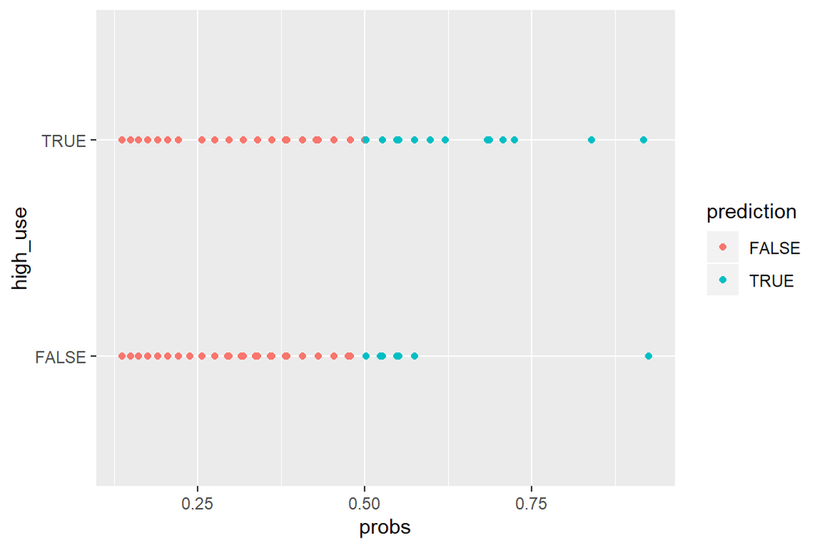

```r
# plot
ggplot(alcs, aes(x = probs, y = high_use, col = prediction)) + geom_point()
```

```r
loss_func <- function(class, prob) {
  n_wrong <- abs(class - prob) > 0.5
  mean(n_wrong)
}
# call the function to compute the average of wrong predictions
loss_func(class = alcs$high_use, prob = alcs$prediction)
```

```
## [1] 0.2565445
```

```r
# 10-fold cross-validation for the model
library(boot)
cv <- cv.glm(data = alcs, cost = loss_func, glmfit = m, K = 10)
# cv.glm computes the error and stores it in delta, print delta
cv$delta[1]
```

```
## [1] 0.2696335
```

.

# 4 Clustering and classification

Today we are first building a Linear Discriminant Model and testing its predictive power. Last week we used logistic regression to predict two categories (true/false). When we have more two, we can use LDA. It focuses on maximizing the separability among known categories. It is a supervized classification method, in contrast to K-means clustering, which is an unsupervized method. We will try that in the end of this exercise.

## Load and explore the dataset

```r
# load the Boston data and explore
library(MASS)
data("Boston")
dim(Boston)
```

```
## [1] 506  14
```

```r
summary(Boston)
```

```
##       crim                zn             indus            chas
##  Min.   : 0.00632   Min.   :  0.00   Min.   : 0.46   Min.   :0.00000
##  1st Qu.: 0.08204   1st Qu.:  0.00   1st Qu.: 5.19   1st Qu.:0.00000
##  Median : 0.25651   Median :  0.00   Median : 9.69   Median :0.00000
##  Mean   : 3.61352   Mean   : 11.36   Mean   :11.14   Mean   :0.06917
##  3rd Qu.: 3.67708   3rd Qu.: 12.50   3rd Qu.:18.10   3rd Qu.:0.00000
##  Max.   :88.97620   Max.   :100.00   Max.   :27.74   Max.   :1.00000
##       nox               rm             age              dis
##  Min.   :0.3850   Min.   :3.561   Min.   :  2.90   Min.   : 1.130
##  1st Qu.:0.4490   1st Qu.:5.886   1st Qu.: 45.02   1st Qu.: 2.100
##  Median :0.5380   Median :6.208   Median : 77.50   Median : 3.207
##  Mean   :0.5547   Mean   :6.285   Mean   : 68.57   Mean   : 3.795
##  3rd Qu.:0.6240   3rd Qu.:6.623   3rd Qu.: 94.08   3rd Qu.: 5.188
##  Max.   :0.8710   Max.   :8.780   Max.   :100.00   Max.   :12.127
##       rad              tax           ptratio          black
##  Min.   : 1.000   Min.   :187.0   Min.   :12.60   Min.   :  0.32
##  1st Qu.: 4.000   1st Qu.:279.0   1st Qu.:17.40   1st Qu.:375.38
##  Median : 5.000   Median :330.0   Median :19.05   Median :391.44
##  Mean   : 9.549   Mean   :408.2   Mean   :18.46   Mean   :356.67
##  3rd Qu.:24.000   3rd Qu.:666.0   3rd Qu.:20.20   3rd Qu.:396.23
##  Max.   :24.000   Max.   :711.0   Max.   :22.00   Max.   :396.90
##      lstat            medv
##  Min.   : 1.73   Min.   : 5.00
##  1st Qu.: 6.95   1st Qu.:17.02
##  Median :11.36   Median :21.20
##  Mean   :12.65   Mean   :22.53
##  3rd Qu.:16.95   3rd Qu.:25.00
##  Max.   :37.97   Max.   :50.00
```

```r
str(Boston)
```

```
## 'data.frame':    506 obs. of  14 variables:
##  $ crim   : num  0.00632 0.02731 0.02729 0.03237 0.06905 ...
##  $ zn     : num  18 0 0 0 0 0 12.5 12.5 12.5 12.5 ...
##  $ indus  : num  2.31 7.07 7.07 2.18 2.18 2.18 7.87 7.87 7.87 7.87 ...
##  $ chas   : int  0 0 0 0 0 0 0 0 0 0 ...
##  $ nox    : num  0.538 0.469 0.469 0.458 0.458 0.458 0.524 0.524 0.524 0.524 ...
##  $ rm     : num  6.58 6.42 7.18 7 7.15 ...
##  $ age    : num  65.2 78.9 61.1 45.8 54.2 58.7 66.6 96.1 100 85.9 ...
##  $ dis    : num  4.09 4.97 4.97 6.06 6.06 ...
##  $ rad    : int  1 2 2 3 3 3 5 5 5 5 ...
##  $ tax    : num  296 242 242 222 222 222 311 311 311 311 ...
##  $ ptratio: num  15.3 17.8 17.8 18.7 18.7 18.7 15.2 15.2 15.2 15.2 ...
##  $ black  : num  397 397 393 395 397 ...
##  $ lstat  : num  4.98 9.14 4.03 2.94 5.33 ...
##  $ medv   : num  24 21.6 34.7 33.4 36.2 28.7 22.9 27.1 16.5 18.9 ...
```

The Boston Housing Dataset consists of price of houses in various places in Boston. Alongside with price, the dataset also provide information such as Crime (CRIM), areas of non-retail business in the town (INDUS), the age of people who own the house (AGE), The data frame has 506 rows and 14 columns.

```r
# 3 Graphical overview
library(tidyverse)
library(corrplot)
cor_matrix <- cor(Boston)
cor_matrix %>% round(2)
```

```
##          crim    zn indus  chas   nox    rm   age   dis   rad   tax
## crim     1.00 -0.20  0.41 -0.06  0.42 -0.22  0.35 -0.38  0.63  0.58
## zn      -0.20  1.00 -0.53 -0.04 -0.52  0.31 -0.57  0.66 -0.31 -0.31
## indus    0.41 -0.53  1.00  0.06  0.76 -0.39  0.64 -0.71  0.60  0.72
## chas    -0.06 -0.04  0.06  1.00  0.09  0.09  0.09 -0.10 -0.01 -0.04
## nox      0.42 -0.52  0.76  0.09  1.00 -0.30  0.73 -0.77  0.61  0.67
## rm      -0.22  0.31 -0.39  0.09 -0.30  1.00 -0.24  0.21 -0.21 -0.29
## age      0.35 -0.57  0.64  0.09  0.73 -0.24  1.00 -0.75  0.46  0.51
## dis     -0.38  0.66 -0.71 -0.10 -0.77  0.21 -0.75  1.00 -0.49 -0.53
## rad      0.63 -0.31  0.60 -0.01  0.61 -0.21  0.46 -0.49  1.00  0.91
## tax      0.58 -0.31  0.72 -0.04  0.67 -0.29  0.51 -0.53  0.91  1.00
## ptratio  0.29 -0.39  0.38 -0.12  0.19 -0.36  0.26 -0.23  0.46  0.46
## black   -0.39  0.18 -0.36  0.05 -0.38  0.13 -0.27  0.29 -0.44 -0.44
## lstat    0.46 -0.41  0.60 -0.05  0.59 -0.61  0.60 -0.50  0.49  0.54
## medv    -0.39  0.36 -0.48  0.18 -0.43  0.70 -0.38  0.25 -0.38 -0.47
##         ptratio black lstat  medv
## crim       0.29 -0.39  0.46 -0.39
## zn        -0.39  0.18 -0.41  0.36
## indus      0.38 -0.36  0.60 -0.48
## chas      -0.12  0.05 -0.05  0.18
## nox        0.19 -0.38  0.59 -0.43
## rm        -0.36  0.13 -0.61  0.70
## age        0.26 -0.27  0.60 -0.38
## dis       -0.23  0.29 -0.50  0.25
## rad        0.46 -0.44  0.49 -0.38
## tax        0.46 -0.44  0.54 -0.47
## ptratio    1.00 -0.18  0.37 -0.51
## black     -0.18  1.00 -0.37  0.33
## lstat      0.37 -0.37  1.00 -0.74
## medv      -0.51  0.33 -0.74  1.00
```

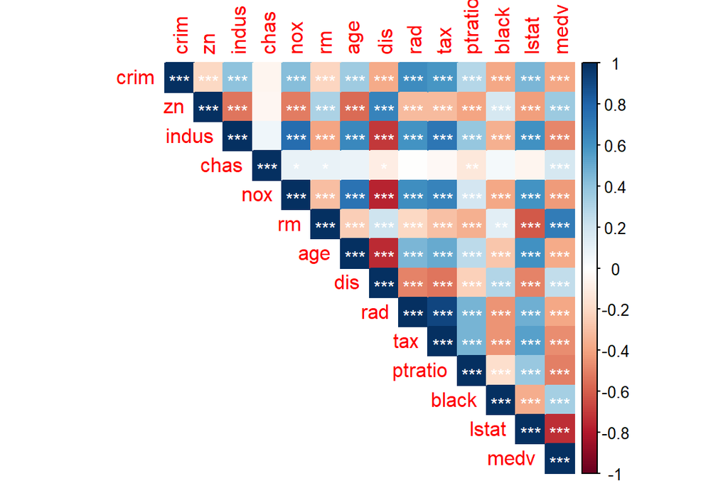

```r
# significance tests for corr matrix
res <- cor.mtest(Boston, conf.level = .95)
# draw the corrplot with sig levels
corrplot(cor_matrix, p.mat = res$p, insig = "label_sig", sig.level = c(.001, .01, .05), pch.cex = .9, pch.col = "white", method="color", type="upper")
```

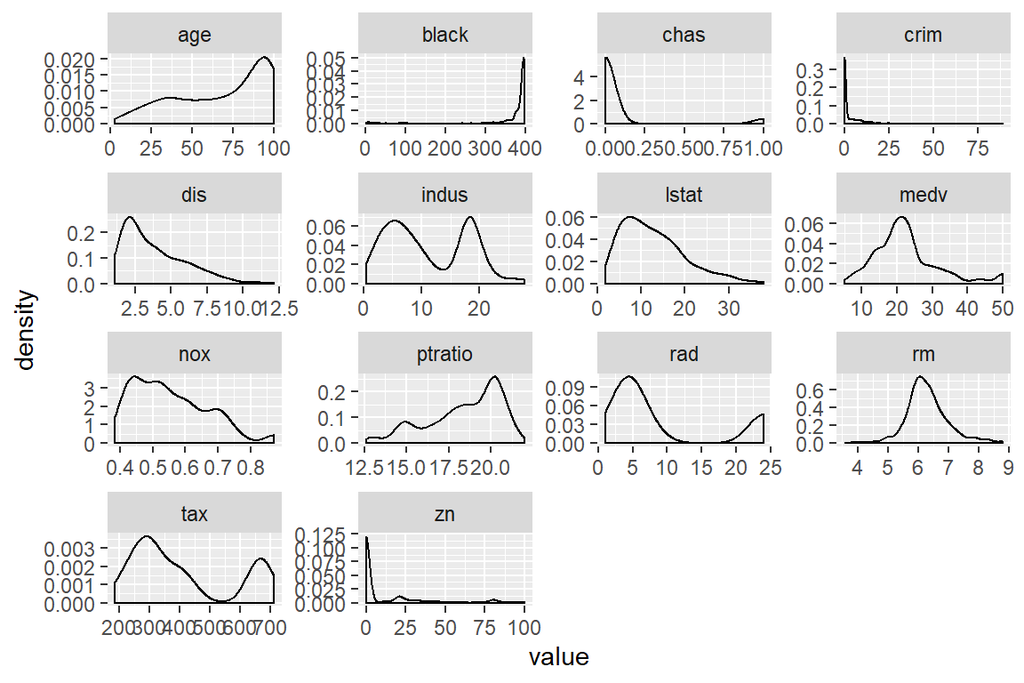

```r
library(ggplot2)
library(purrr)
# keeo() drops all factor variables from plotting
# gather() unpivots data to key - value pairs
# ggplot () draws densityplot from all remaining variables
Boston %>% keep(is.numeric) %>% gather() %>%
  ggplot(aes(value)) + facet_wrap(~ key, scales = "free") + geom_density()
```

The distributions of all variables are shown above. Only RM and MEDV are close to normal distribution.

## Stardardize the dataset and create the categorical target variable

```r
# scale all variables and convert into dataframe format
boston_scaled <- scale(Boston)
boston_scaled <- as.data.frame(boston_scaled)
summary(boston_scaled)
```

```
##       crim                 zn               indus
##  Min.   :-0.419367   Min.   :-0.48724   Min.   :-1.5563
##  1st Qu.:-0.410563   1st Qu.:-0.48724   1st Qu.:-0.8668
##  Median :-0.390280   Median :-0.48724   Median :-0.2109
##  Mean   : 0.000000   Mean   : 0.00000   Mean   : 0.0000
##  3rd Qu.: 0.007389   3rd Qu.: 0.04872   3rd Qu.: 1.0150
##  Max.   : 9.924110   Max.   : 3.80047   Max.   : 2.4202
##       chas              nox                rm               age
##  Min.   :-0.2723   Min.   :-1.4644   Min.   :-3.8764   Min.   :-2.3331
##  1st Qu.:-0.2723   1st Qu.:-0.9121   1st Qu.:-0.5681   1st Qu.:-0.8366
##  Median :-0.2723   Median :-0.1441   Median :-0.1084   Median : 0.3171
##  Mean   : 0.0000   Mean   : 0.0000   Mean   : 0.0000   Mean   : 0.0000
##  3rd Qu.:-0.2723   3rd Qu.: 0.5981   3rd Qu.: 0.4823   3rd Qu.: 0.9059
##  Max.   : 3.6648   Max.   : 2.7296   Max.   : 3.5515   Max.   : 1.1164
##       dis               rad               tax             ptratio
##  Min.   :-1.2658   Min.   :-0.9819   Min.   :-1.3127   Min.   :-2.7047
##  1st Qu.:-0.8049   1st Qu.:-0.6373   1st Qu.:-0.7668   1st Qu.:-0.4876
##  Median :-0.2790   Median :-0.5225   Median :-0.4642   Median : 0.2746
##  Mean   : 0.0000   Mean   : 0.0000   Mean   : 0.0000   Mean   : 0.0000
##  3rd Qu.: 0.6617   3rd Qu.: 1.6596   3rd Qu.: 1.5294   3rd Qu.: 0.8058
##  Max.   : 3.9566   Max.   : 1.6596   Max.   : 1.7964   Max.   : 1.6372
##      black             lstat              medv
##  Min.   :-3.9033   Min.   :-1.5296   Min.   :-1.9063
##  1st Qu.: 0.2049   1st Qu.:-0.7986   1st Qu.:-0.5989
##  Median : 0.3808   Median :-0.1811   Median :-0.1449
##  Mean   : 0.0000   Mean   : 0.0000   Mean   : 0.0000
##  3rd Qu.: 0.4332   3rd Qu.: 0.6024   3rd Qu.: 0.2683
##  Max.   : 0.4406   Max.   : 3.5453   Max.   : 2.9865
```

```r
# create a quantile vector / categorical variable from CRIM (crime rate)
bins <- quantile(boston_scaled$crim)
crimelabels <- c()
crime <- cut(boston_scaled$crim, breaks = bins, include.lowest = TRUE, labels = c("low", "med_low", "med_high", "high"))
# add the new CRIME to the dataset
boston_scaled$crime <- crime
table(crime)
```

```
## crime
##      low  med_low med_high     high
##      127      126      126      127
```

The data is now split into four quartiles based on the crime rate. Vector Crime was added to the dataframe.

## Divide into train and test datasets

```r
# divide the dataset to train and test
# count the n of rows
n <- nrow(boston_scaled)
# random select 80% of rows and save row numbers into IND
ind <- sample(n, size = n * 0.8)
# create train and test datasets based on IND
train <- boston_scaled[ind,]
test <- boston_scaled[-ind,]
```

## Build the LDA model

```r
# drop the rows with missing values in CRIME
train <- train[complete.cases(crime),]
# create the LDA model with crime as target and all other variables (~.) as predictors
lda.fit <- lda(crime ~., data = train)
lda.fit
```

```
## Call:
## lda(crime ~ ., data = train)
##
## Prior probabilities of groups:
##       low   med_low  med_high      high
## 0.2351485 0.2400990 0.2747525 0.2500000
##
## Group means:
##                crim          zn      indus        chas        nox
## low      -0.4147518  0.85097781 -0.8699015 -0.10655643 -0.8378282
## med_low  -0.4036392 -0.09515751 -0.3507642  0.01179157 -0.5744967
## med_high -0.2969160 -0.37753652  0.1779221  0.08236465  0.3607290
## high      1.1150479 -0.48724019  1.0171306 -0.07742312  1.0836623
##                  rm        age        dis        rad        tax
## low       0.3391490 -0.8883656  0.8026593 -0.6977767 -0.6968029
## med_low  -0.1274108 -0.3426428  0.3512465 -0.5449801 -0.4333839
## med_high  0.1621554  0.4218518 -0.3779908 -0.3962565 -0.2856763
## high     -0.4260601  0.8217046 -0.8522141  1.6379981  1.5139626
##              ptratio       black       lstat        medv
## low      -0.39712044  0.38489823 -0.75007426  0.44451452
## med_low  -0.08565135  0.35900541 -0.18155078  0.01537663
## med_high -0.28240408  0.08869513 -0.03111055  0.21350091
## high      0.78062517 -0.84051849  0.88288814 -0.73076537
##
## Coefficients of linear discriminants:
##                 LD1         LD2         LD3
## crim     0.22138459  0.12406288 -0.14739328
## zn       0.10328255  0.57822965 -1.06112482
## indus    0.01845306 -0.35873462 -0.04086287
## chas    -0.05182353 -0.02894410  0.15298211
## nox      0.46033888 -0.74764140 -1.21061617
## rm      -0.08378467 -0.15627268 -0.14997887
## age      0.32633619 -0.40249149 -0.02639298
## dis      0.03558988 -0.24008725  0.16497663
## rad      2.93720740  0.76722689 -0.25896799
## tax     -0.05820532  0.19424521  0.97625216
## ptratio  0.15988289 -0.05392524 -0.33223230
## black   -0.14113708  0.05919551  0.15776034
## lstat    0.23033772 -0.26607444  0.42212201
## medv     0.22634825 -0.49197451 -0.13627499
##
## Proportion of trace:
##    LD1    LD2    LD3
## 0.9470 0.0409 0.0121
```

Results show the group-specific means for each covariate, for which the LDA tries to maximize the difference between groups.

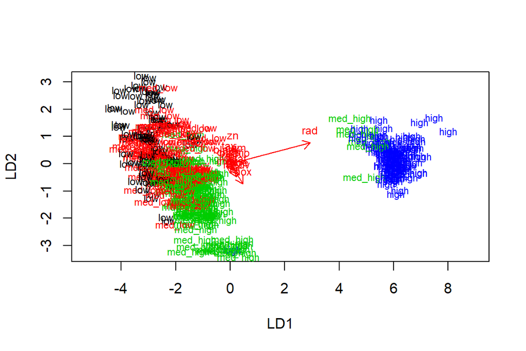

```r
# draw the LDA(bi) plot
# the function for lda biplot arrows
lda.arrows <- function(x, myscale = 1, arrow_heads = 0.1, color = "red", tex = 0.75, choices = c(1,2)){
  heads <- coef(x)
  arrows(x0 = 0, y0 = 0,
         x1 = myscale * heads[,choices[1]],
         y1 = myscale * heads[,choices[2]], col=color, length = arrow_heads)
  text(myscale * heads[,choices], labels = row.names(heads),
       cex = tex, col=color, pos=3)
}

# target classes as numeric
classes <- as.numeric(train$crime)

# plot the lda results
plot(lda.fit, dimen = 2, col = classes, pch = classes)
lda.arrows(lda.fit, myscale = 1)
```

We can see, that the category “high” is best separated. From the numeric results we saw, that LD1 (x-axis) explained 95% of the between-group variance.